# Pendugaan Parameter, Diagnostik Model, dan Peramalan

Kaylila Kireinahana

2023-10-15

# Packages

```r
library(ggplot2)
library(tsibble)
library(tseries)
library(MASS)
library(forecast)
library(TSA)
library(TTR)
library(aTSA)
library(graphics)
```

# Penyiapan Data

```r
summary(cars)
```

```
##      speed           dist
##  Min.   : 4.0   Min.   :  2.00
##  1st Qu.:12.0   1st Qu.: 26.00
##  Median :15.0   Median : 36.00
##  Mean   :15.4   Mean   : 42.98
##  3rd Qu.:19.0   3rd Qu.: 56.00
##  Max.   :25.0   Max.   :120.00
```

# Eksplorasi Data

```r
data_mpdw <- rio::import("https://raw.githubusercontent.com/reiflection/MPDW/main/Data/Cerial%20Prices.csv")
View(data_mpdw)
rice <- ts(data_mpdw$Price_rice_ton)
rice.train <- ts(rice[1:288])
rice.test <- ts(rice[289:360])
```

## Plot Data Time Series

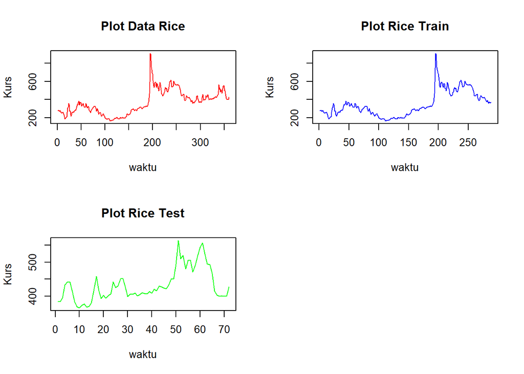

```r
par(mfrow=c(2,2))
plot.ts(rice, lty=1, col="red", xlab="waktu", ylab="Kurs", main="Plot Data Rice")
plot.ts(rice.train, lty=1, col="blue", xlab="waktu", ylab="Kurs", main="Plot Rice Train")
plot.ts(rice.test, lty=1, col="green", xlab="waktu", ylab="Kurs", main="Plot Rice Test")
```

Terlihat dari ketiga plot tersebut, bahwa data tidak memiliki pola yang konstan serta tidak bergerak pada nilai tengah tertentu. Hal ini menunjukkan bahwa data tidak stasioner.

## Uji Kestasioneran

### Uji ACF

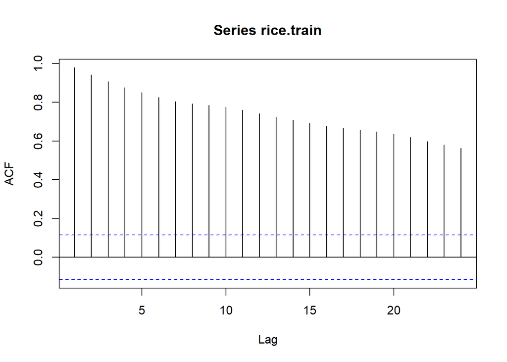

```r
acf(rice.train)
```

Berdasarkan plot ACF tersebut, terlihat bahwa nilai ACF terhadap lag menurun secara perlahan. Hal ini menunjukkan bahwa data tidak stasioner dalam rataan.

### Uji ADF

```r
tseries::adf.test(rice.train)
```

```
##
##  Augmented Dickey-Fuller Test
##
## data:  rice.train
## Dickey-Fuller = -2.1721, Lag order = 6, p-value = 0.5036
## alternative hypothesis: stationary
```

$H_0$: Data tidak stasioner dalam rataan

$H_1$: Data stasioner dalam rataan

Berdasarkan uji tersebut,
$$p-value >
\alpha$$
(
$$0.5036 > 0.05$$
) yang berarti tak tolak H0 atau data tidak stasioner dalam rataan.

### Plot Box-Cox

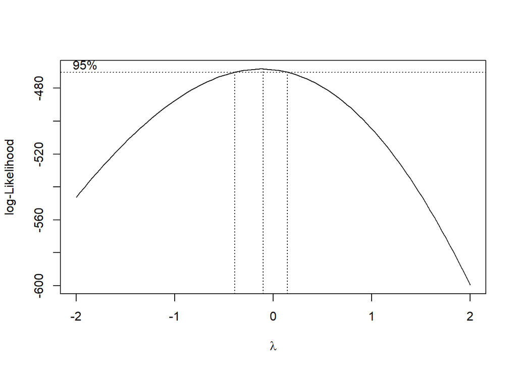

```r
rice.index <- seq(1:288)
rice.bc = boxcox(rice.train ~ rice.index, lambda = seq(-2,2,by=0.1))
```

```r
#Nilai Rounded Lambda
rice.lambda <- rice.bc$x[which.max(rice.bc$y)]
rice.lambda
```

```
## [1] -0.1010101
```

```r
#SK
rice.bc$x[rice.bc$y > max(rice.bc$y) - 1/2 * qchisq(.95,1)]
```

```
##  [1] -0.38383838 -0.34343434 -0.30303030 -0.26262626 -0.22222222 -0.18181818
##  [7] -0.14141414 -0.10101010 -0.06060606 -0.02020202  0.02020202  0.06060606
## [13]  0.10101010  0.14141414
```

Dari hasil diatas, terlihat bahwa lambda optimum adalah $-0.1010101$ dengan batas bawah $-0.38383838$ dan batas atas $0.14141414$. Karena selang tidak memuat nilai satu, maka data tidak stasioner dalam ragam.

## Penanganan Ketidakstasioneran Data

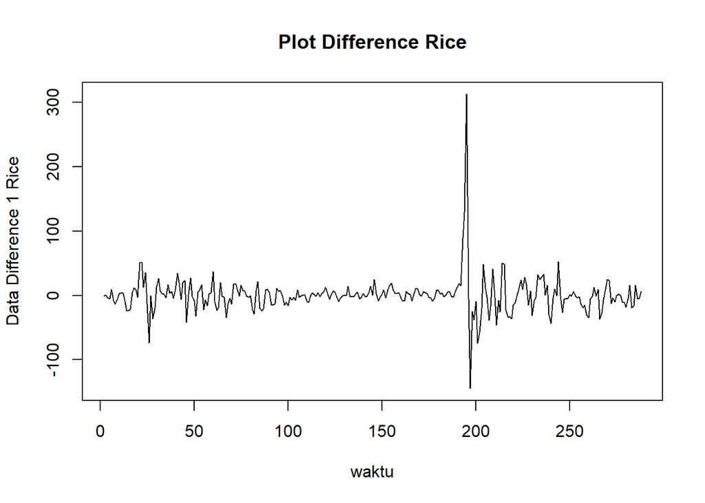

```r
rice.train.diff <- diff(rice.train, differences = 1)
plot.ts(rice.train.diff, lty=1, xlab="waktu", ylab="Data Difference 1 Rice", main="Plot Difference Rice")
```

Berdasarkan plot diatas, data setelah mengalami *differencing* menunjukkan pola yang stasioner namun terdapat satu lonjakan. Untuk memastikan lebih lanjut, dilakukan uji formal.

### Plot ACF

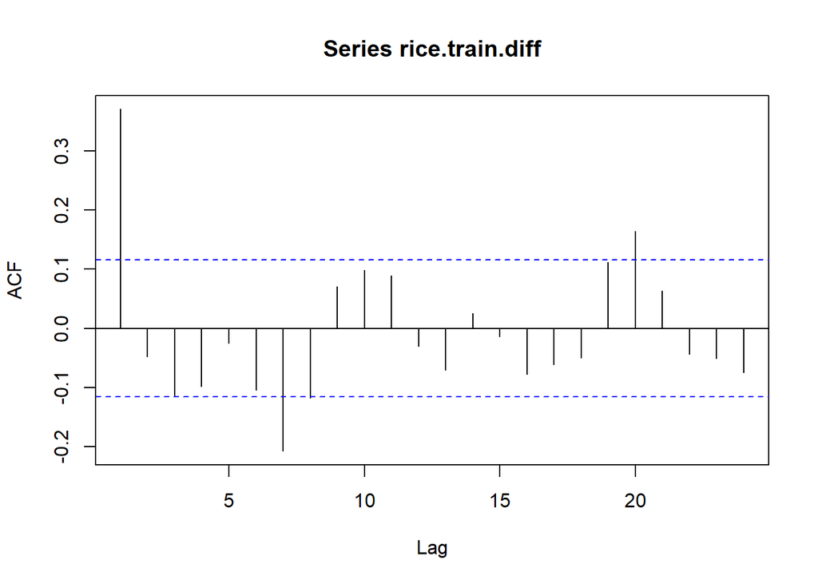

```r
acf(rice.train.diff)
```

Berdasarkan plot diatas, ACF cenderung *cuts off* di lag pertama.

### Uji ADF

```r
tseries::adf.test(rice.train.diff)
```

```
##
##  Augmented Dickey-Fuller Test
##
## data:  rice.train.diff
## Dickey-Fuller = -8.3721, Lag order = 6, p-value = 0.01
## alternative hypothesis: stationary
```

$H_0$: Data tidak stasioner dalam rataan

$H_1$: Data stasioner dalam rataan

Berdasarkan uji tersebut,
$$p-value (0.01)
< \alpha (0.05)$$
yang berarti tolak H0. Hal ini menandakan bahwa data *differencing* sudah stasioner dalam rataan.

### Plot PACF

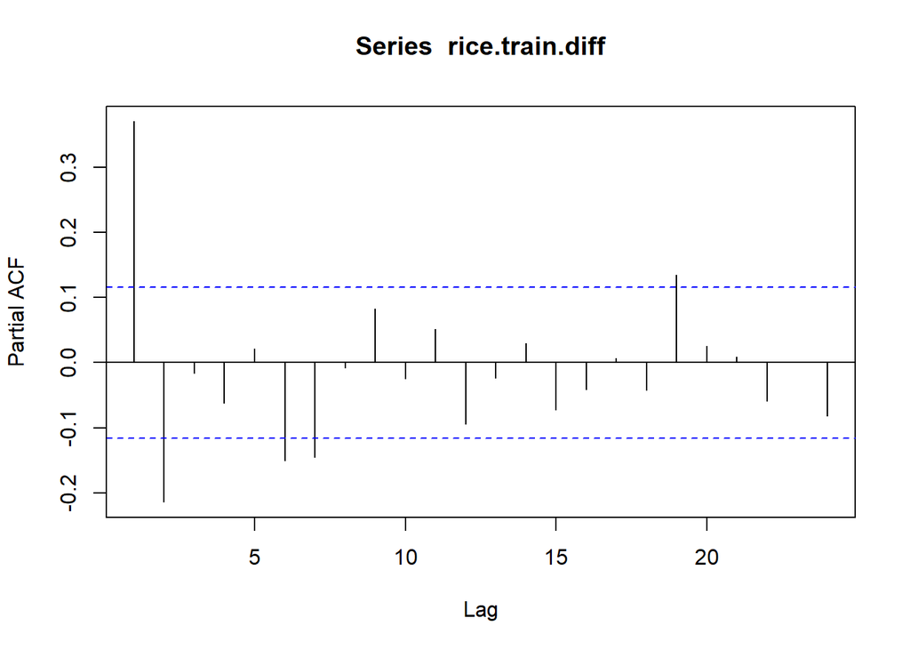

```r
pacf(rice.train.diff)
```

Berdasarkan plot tersebut, PACF cenderung *cuts off* di lag kedua.

### Plot EACF

```r
eacf(rice.train.diff)
```

```
## AR/MA
##   0 1 2 3 4 5 6 7 8 9 10 11 12 13
## 0 x o o o o o x o o o o  o  o  o
## 1 x x o o o o x x x o o  o  o  o
## 2 o x x o o o o o x o o  o  o  o
## 3 x x o x o o o o o o o  o  o  o
## 4 x x o x o o o x o o o  o  o  o
## 5 x x x x x o o x o o o  o  o  o
## 6 x x o x o o o x o o o  o  o  o
## 7 o x o o o x o o o o o  o  o  o
```

Berdasarkan plot EACF, beberapa model yang terbentuk adalah ARIMA(0,1,1), ARIMA(0,1,2), ARIMA(1,1,2), dan ARIMA(2,1,0).

# Pendugaan Parameter Model Tentatif

## ARIMA(0,1,1)

```r
rice.model1 = Arima(rice.train.diff, order=c(0,1,1),method="ML")
summary(rice.model1) #AIC=2740.94
```

```
## Series: rice.train.diff
## ARIMA(0,1,1)
##
## Coefficients:
##           ma1
##       -1.0000
## s.e.   0.0112
##
## sigma^2 = 825.1:  log likelihood = -1368.47
## AIC=2740.94   AICc=2740.98   BIC=2748.25
##
## Training set error measures:
##                     ME     RMSE      MAE  MPE MAPE      MASE      ACF1
## Training set 0.1707505 28.62482 14.73214 -Inf  Inf 0.8715063 0.3703446
```

```r
lmtest::coeftest(rice.model1) #seluruh parameter signifikan
```

```
##
## z test of coefficients:
##
##      Estimate Std. Error z value  Pr(>|z|)
## ma1 -1.000000   0.011223 -89.106 < 2.2e-16 ***
## ---
## Signif. codes:  0 '***' 0.001 '**' 0.01 '*' 0.05 '.' 0.1 ' ' 1
```

## ARIMA(0,1,2)

```r
rice.model2 = Arima(rice.train.diff, order=c(0,1,2),method="ML")
summary(rice.model2) #AIC=2688.53
```

```
## Series: rice.train.diff
## ARIMA(0,1,2)
##
## Coefficients:
##           ma1      ma2
##       -0.5432  -0.4568
## s.e.   0.0538   0.0531
##
## sigma^2 = 685.8:  log likelihood = -1341.27
## AIC=2688.53   AICc=2688.62   BIC=2699.5
##
## Training set error measures:
##                     ME    RMSE     MAE MPE MAPE     MASE         ACF1
## Training set 0.1273435 26.0514 13.7721 NaN  Inf 0.814713 -0.001278633
```

```r
lmtest::coeftest(rice.model2) #seluruh parameter signifikan
```

```
##
## z test of coefficients:
##
##      Estimate Std. Error  z value  Pr(>|z|)
## ma1 -0.543220   0.053772 -10.1024 < 2.2e-16 ***
## ma2 -0.456759   0.053063  -8.6079 < 2.2e-16 ***
## ---
## Signif. codes:  0 '***' 0.001 '**' 0.01 '*' 0.05 '.' 0.1 ' ' 1
```

## ARIMA(1,1,2)

```r
rice.model3 = Arima(rice.train.diff, order=c(1,1,2),method="ML")
summary(rice.model3) #AIC=2690.53
```

```
## Series: rice.train.diff
## ARIMA(1,1,2)
##
## Coefficients:
##          ar1      ma1      ma2
##       0.0029  -0.5456  -0.4544
## s.e.  0.1331   0.1196   0.1193
##
## sigma^2 = 688.3:  log likelihood = -1341.27
## AIC=2690.53   AICc=2690.67   BIC=2705.15
##
## Training set error measures:
##                     ME     RMSE      MAE MPE MAPE      MASE         ACF1
## Training set 0.1272679 26.05132 13.77188 NaN  Inf 0.8147003 -0.001758298
```

```r
lmtest::coeftest(rice.model3) #tidak seluruh parameter signifikan
```

```
##
## z test of coefficients:
##
##       Estimate Std. Error z value  Pr(>|z|)
## ar1  0.0028535  0.1330944  0.0214 0.9828951
## ma1 -0.5455605  0.1196320 -4.5603 5.108e-06 ***
## ma2 -0.4544388  0.1193145 -3.8087 0.0001397 ***
## ---
## Signif. codes:  0 '***' 0.001 '**' 0.01 '*' 0.05 '.' 0.1 ' ' 1
```

## ARIMA(2,1,0)

```r
rice.model4 = Arima(rice.train.diff, order=c(2,1,0),method="ML")
summary(rice.model4) #AIC=2765.17
```

```
## Series: rice.train.diff
## ARIMA(2,1,0)
##
## Coefficients:
##           ar1      ar2
##       -0.2206  -0.3140
## s.e.   0.0561   0.0559
##
## sigma^2 = 912.1:  log likelihood = -1379.59
## AIC=2765.17   AICc=2765.26   BIC=2776.14
##
## Training set error measures:
##                      ME     RMSE      MAE MPE MAPE      MASE        ACF1
## Training set 0.01724131 30.04312 15.98831 Inf  Inf 0.9458174 -0.06573154
```

```r
lmtest::coeftest(rice.model4) #seluruh parameter signifikan
```

```
##
## z test of coefficients:
##
##      Estimate Std. Error z value  Pr(>|z|)
## ar1 -0.220589   0.056064 -3.9346 8.334e-05 ***
## ar2 -0.314035   0.055893 -5.6185 1.927e-08 ***
## ---
## Signif. codes:  0 '***' 0.001 '**' 0.01 '*' 0.05 '.' 0.1 ' ' 1
```

Berdasarkan beberapa model tentatif diatas, model terbaik dengan AIC terkecil dan seluruh parameter signifikan adalah ARIMA(0,1,2)

## Overfitting

Tahapan selanjutnya adalah overfitting dengan menaikkan ordo AR(p) atau MA(q). Jika model terbaik yang diperoleh adalah ARIMA(0,1,2) maka dilakukan pemodelan untuk ARIMA(0,1,3) dan ARIMA(1,1,2)

### ARIMA(1,1,2)

```r
rice.model3 = Arima(rice.train.diff, order=c(1,1,2),method="ML")
summary(rice.model3) #AIC=2690.53
```

```
## Series: rice.train.diff
## ARIMA(1,1,2)
##
## Coefficients:
##          ar1      ma1      ma2
##       0.0029  -0.5456  -0.4544
## s.e.  0.1331   0.1196   0.1193
##
## sigma^2 = 688.3:  log likelihood = -1341.27
## AIC=2690.53   AICc=2690.67   BIC=2705.15
##
## Training set error measures:
##                     ME     RMSE      MAE MPE MAPE      MASE         ACF1
## Training set 0.1272679 26.05132 13.77188 NaN  Inf 0.8147003 -0.001758298
```

```r
lmtest::coeftest(rice.model3) #tidak seluruh parameter signifikan
```

```
##
## z test of coefficients:
##
##       Estimate Std. Error z value  Pr(>|z|)
## ar1  0.0028535  0.1330944  0.0214 0.9828951
## ma1 -0.5455605  0.1196320 -4.5603 5.108e-06 ***
## ma2 -0.4544388  0.1193145 -3.8087 0.0001397 ***
## ---
## Signif. codes:  0 '***' 0.001 '**' 0.01 '*' 0.05 '.' 0.1 ' ' 1
```

### ARIMA(0,1,3)

```r
rice.model2a = Arima(rice.train.diff, order=c(0,1,3),method="ML")
summary(rice.model2a) #AIC=2690.53
```

```
## Series: rice.train.diff
## ARIMA(0,1,3)
##
## Coefficients:
##           ma1      ma2      ma3
##       -0.5427  -0.4558  -0.0015
## s.e.   0.0609   0.0650   0.0659
##
## sigma^2 = 688.3:  log likelihood = -1341.27
## AIC=2690.53   AICc=2690.67   BIC=2705.15
##
## Training set error measures:
##                     ME     RMSE      MAE MPE MAPE      MASE         ACF1
## Training set 0.1272631 26.05151 13.77182 NaN  Inf 0.8146965 -0.001768037
```

```r
lmtest::coeftest(rice.model2a) #tidak seluruh parameter signifikan
```

```
##
## z test of coefficients:
##
##       Estimate Std. Error z value  Pr(>|z|)
## ma1 -0.5426772  0.0609362 -8.9057 < 2.2e-16 ***
## ma2 -0.4557918  0.0649535 -7.0172 2.264e-12 ***
## ma3 -0.0015108  0.0659007 -0.0229    0.9817
## ---
## Signif. codes:  0 '***' 0.001 '**' 0.01 '*' 0.05 '.' 0.1 ' ' 1
```

# Peramalan

Peramalan untuk 72 periode kedepan.

```r
rice.ramalan <- forecast::forecast(rice.model2, h = 72)
rice.ramalan
```

```
##     Point Forecast     Lo 80    Hi 80     Lo 95    Hi 95
## 289      2.7492762 -30.87087 36.36942 -48.66830 54.16685
## 290      0.3222793 -36.68738 37.33194 -56.27911 56.92367
## 291      0.3222793 -36.68738 37.33194 -56.27911 56.92367
## 292      0.3222793 -36.68738 37.33194 -56.27911 56.92367
## 293      0.3222793 -36.68738 37.33194 -56.27911 56.92367
## 294      0.3222793 -36.68738 37.33194 -56.27911 56.92367
## 295      0.3222793 -36.68738 37.33194 -56.27911 56.92367
## 296      0.3222793 -36.68738 37.33194 -56.27911 56.92367
## 297      0.3222793 -36.68738 37.33194 -56.27911 56.92367
## 298      0.3222793 -36.68738 37.33194 -56.27911 56.92367
## 299      0.3222793 -36.68738 37.33194 -56.27911 56.92367
## 300      0.3222793 -36.68738 37.33194 -56.27911 56.92367
## 301      0.3222793 -36.68738 37.33194 -56.27911 56.92367
## 302      0.3222793 -36.68738 37.33194 -56.27911 56.92367
```

[output cut: 58 more lines]

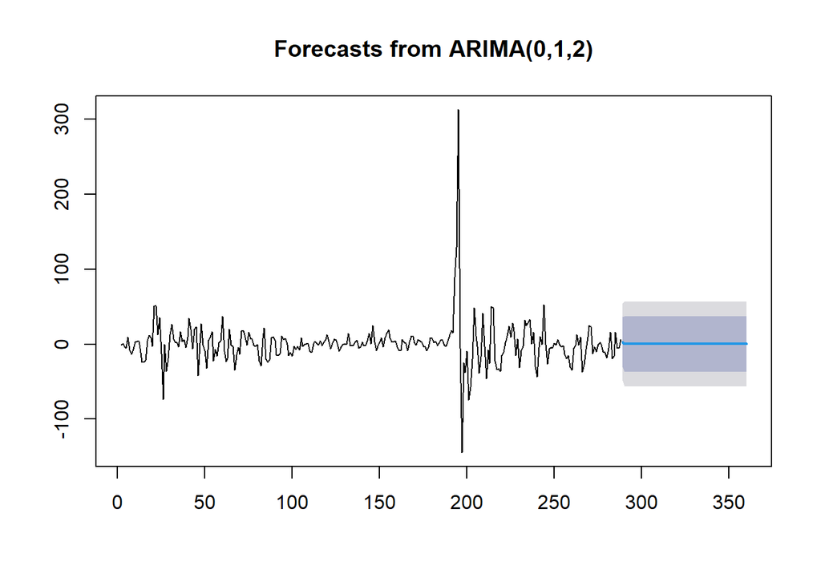

```r
rice.data.ramalan <- rice.ramalan$mean
plot(rice.ramalan)
```

Ramalan ARIMA(0,1,2) cukup stabil hingga akhir periode.

## Plot Peramalan

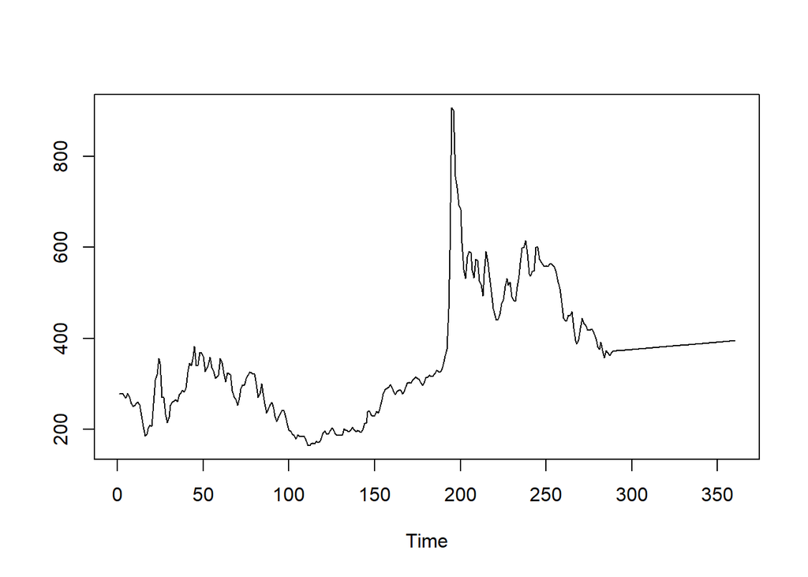

```r
rice.pt <- rice.train[288] #nilai akhir data latih
rice.hasil.diff <- rice.data.ramalan
rice.hasil <- diffinv(rice.hasil.diff, differences = 1) + rice.pt
ts.plot(rice.train, rice.hasil)
```

## Perbandingan Akurasi

```r
rice.perbandingan <- matrix(data=c(head(rice.test, n=72), rice.hasil[-1]),
                     nrow = 72, ncol = 2)
colnames(rice.perbandingan) <- c("Aktual","Hasil Forecast")
rice.perbandingan
```

```
##       Aktual Hasil Forecast
##  [1,]    384       371.7493
##  [2,]    384       372.0716
##  [3,]    395       372.3938
##  [4,]    433       372.7161
##  [5,]    441       373.0384
##  [6,]    442       373.3607
##  [7,]    415       373.6830
##  [8,]    384       374.0052
##  [9,]    369       374.3275
## [10,]    365       374.6498
## [11,]    373       374.9721
## [12,]    377       375.2943
## [13,]    367       375.6166
## [14,]    370       375.9389
```

[output cut: 58 more lines]

```r
accuracy(ts(rice.hasil[-1]), head(rice.test, n=72))
```

```
##               ME     RMSE      MAE    MPE     MAPE      ACF1 Theil's U
## Test set 49.0737 66.06797 49.94883 10.451 10.68903 0.8679511  2.811199
```

Berdasarkan hasil diatas, MAPE yang diperoleh sebesar $10.68903$.